# 📈📊 Sales Forecasting

Arindam Baruah

2023-07-11

# 1 Importing the relevant libraries and dataset 🛠️

First, we import the required libraries which we will use to perform the current analysis.

```r
library(tidyverse)
library(naniar)
library(bookdown)
library(stringr)
library(stringi)
library(lubridate)
library(DT)
library(forcats)
library(ggthemes)
library(corrplot)
library(mltools)
library(data.table)
library(visdat)
library(janitor)
library(cowplot)
library(caTools)
library(pscl)
library(ROCR)
library(caret)
library(xgboost)
library(randomForest)
library(lightgbm)
library(Matrix)
library(catboost)
library(magrittr)
library(fmsb)
library(plotly)
```

# 2 Introduction

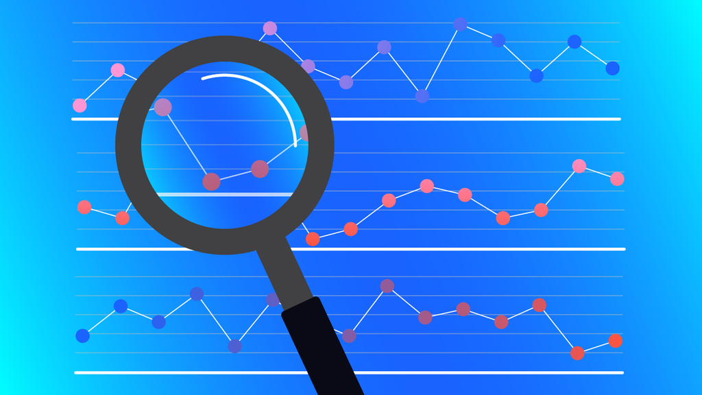

**What are we trying to study ?**

**Time series forecasting** is a powerful analytical technique used to predict future values based on historical data. It plays a crucial role in various domains such as finance, economics, weather forecasting, supply chain management, and more. By analyzing patterns, trends, and dependencies within a time series dataset, forecasting models aim to provide accurate predictions and insights into future behavior.

The first step in time series forecasting is to understand the characteristics of the data. Time series data consists of a sequence of observations collected over time, where each observation is associated with a specific timestamp. These observations may exhibit trends, seasonality, cyclic patterns, or irregularities, which need to be identified and accounted for in the forecasting process.

**- The internet**

We will use one dataset for the purpose of exploratory data analysis and training the prediction model while the test dataset for testing the prediction model on a completely new dataset.

After reading the data, let us see how the train dataset looks like.

```r
df_train <- read_csv("data/train.csv")
df_test <-  read_csv("data/test.csv")
head(df_train)
```

```
## # A tibble: 6 × 6
##      id date       country   store        product                       num_sold
##   <dbl> <date>     <chr>     <chr>        <chr>                            <dbl>
## 1     0 2017-01-01 Argentina Kaggle Learn Using LLMs to Improve Your C…       63
## 2     1 2017-01-01 Argentina Kaggle Learn Using LLMs to Train More LLMs       66
## 3     2 2017-01-01 Argentina Kaggle Learn Using LLMs to Win Friends an…        9
## 4     3 2017-01-01 Argentina Kaggle Learn Using LLMs to Win More Kaggl…       59
## 5     4 2017-01-01 Argentina Kaggle Learn Using LLMs to Write Better          49
## 6     5 2017-01-01 Argentina Kaggle Store Using LLMs to Improve Your C…       88
```

We observe that the dataset is fairly simple with the following features.

1. **Date**: The date of purchase associated for a particular product.
2. **Country**: The originating country where the purchase was made.
3. **Store**: The store associated with the purchase product.
4. **Product**: The type of product purchased.
5. **num_sold**: Number of products sold.

# 3 Data cleaning

## 3.1 Removal of unnecessary variables

The dataset appears to be fairly simple and concise. We will retain all the available features in this dataset except for the “id” column.

```r
df_train <- df_train %>% select(-id)
```

## 3.2 Check for null values

In this step, we will try to check for the presence of null values in the dataset.

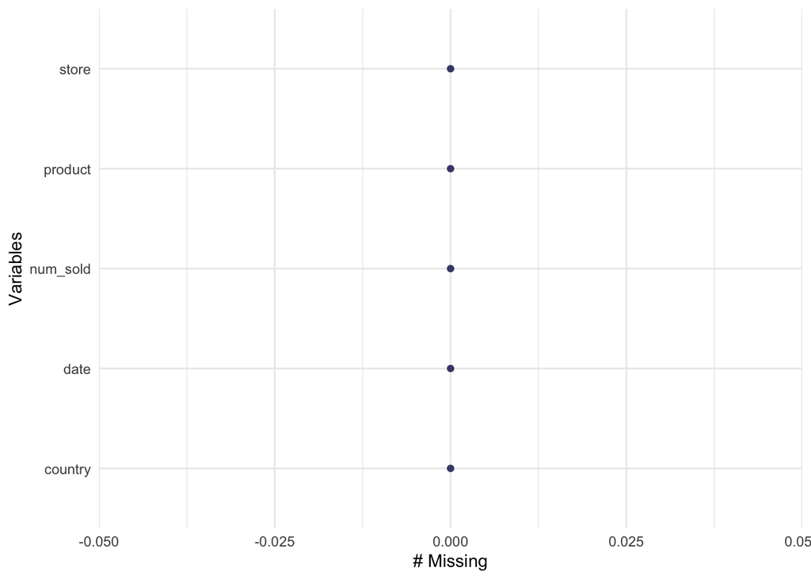

Figure 3.1: Missingness in the dataset

```r
gg_miss_var(df_train)
```

Based on the figure 3.1, we can observe that

✅ The dataset does not contain any missing values. This indicates that we have a clean dataset which is ready for EDA and further analysis.

# 4 Exploratory Data Analysis

In this section, we will try to visualise the various features and try to obtain key insights through the usage of these visualisations.

## 4.1 Sales in each country

Let us try to observe the number of product sales for each country.

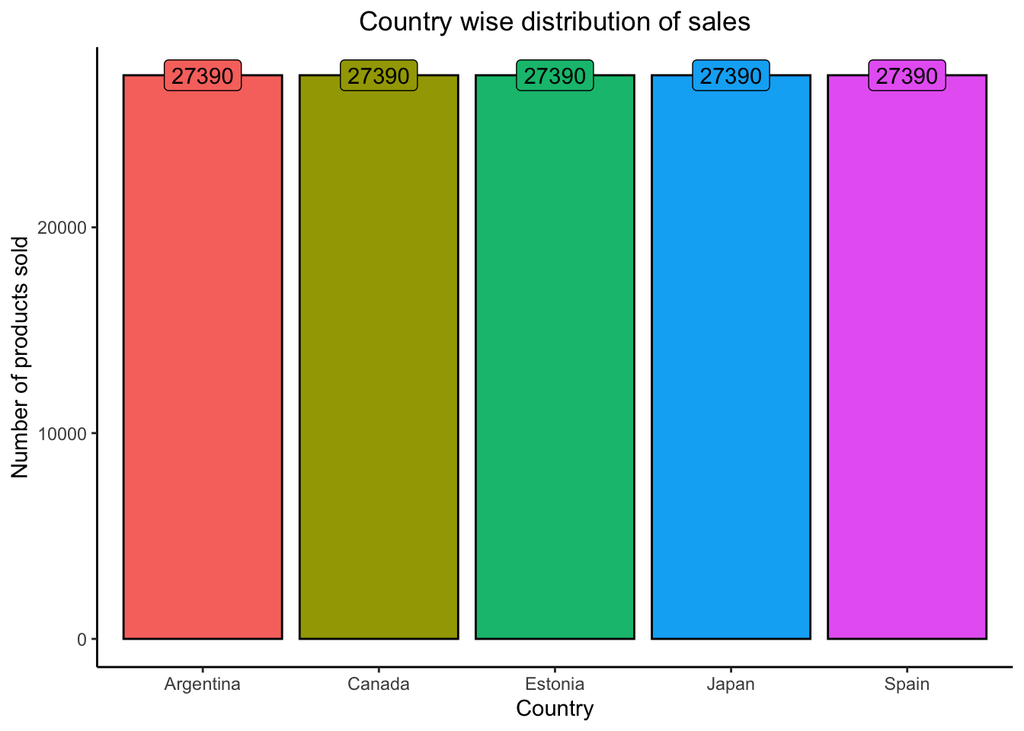

Figure 4.1: Country wise distribution of sales

```r
df_sales_count <- df_train %>% group_by(country) %>% summarise(count = n())
pl1 <- ggplot(data = df_sales_count,aes(x = country,y = count,fill = country)) + geom_col(color = 'black') + theme_classic() + geom_label(aes(label = count)) + labs(x = "Country",y = "Number of products sold") + ggtitle("Country wise distribution of sales") + theme(legend.position = 'none',plot.title = element_text(hjust = 0.5))
pl1
```

## 4.2 Global sales

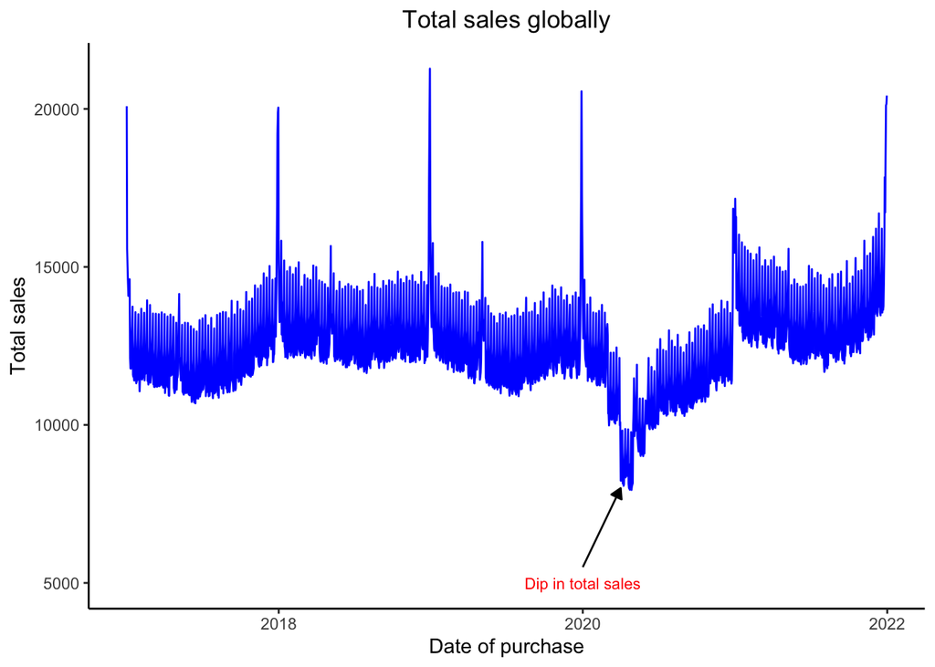

Figure 4.2: Total courses sold

```r
df_date_sale <- df_train %>% group_by(date) %>% summarise(tot_sold =  sum(num_sold))


pl2 <- ggplot(data = df_date_sale,aes(x = date,y = tot_sold),group = date) + geom_line(color = 'blue') + theme_classic() + ggtitle("Total sales globally") + labs(y = "Total sales",x = "Date of purchase") + theme(plot.title = element_text(hjust = 0.5)) +
    annotate("segment",x = ymd(20200101),
    y = 5500,xend = ymd(20200401) ,
    yend = 8000 ,arrow = arrow(type = "closed",
                              length = unit(0.02, "npc"))
  ) +
  annotate("text",x = ymd(20200101),
    y = 5000,colour = "red",
    label = 'Dip in total sales',
    size = unit(3, "pt"))

pl2
```

Based on figure 4.2, we can observe that

💡 there is a **strong seasonality** observed in the data. The sales are observed to peak during the period of new year everytime. However, an unexpected drop in sales were observed in the year of 2020. The sales could be affected as a result of COVID-19 restrictions. 💡

## 4.3 Sales in each country

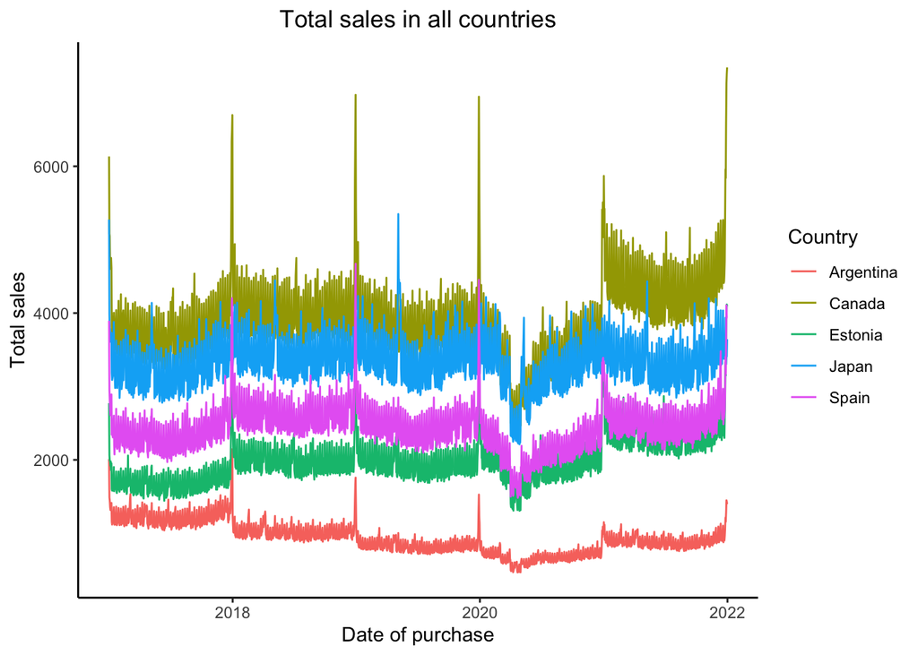

Figure 4.3: Total courses sold in each country

```r
df_date_sale_country <- df_train %>% group_by(date,country) %>% summarise(tot_sold =  sum(num_sold))


pl3 <-ggplot(data = df_date_sale_country,
         aes(x = date, y = tot_sold, color = country),
         group = date) + geom_line() + theme_classic() + ggtitle("Total sales in all countries") + labs(y = "Total sales", x = "Date of purchase", color =
                                                                                                          "Country") + theme(plot.title = element_text(hjust = 0.5))

pl3
```

Based on figure 4.3, we can observe that

💡 the **strong seasonality** is observed equally in each of the 5 countries. The peaks and troughs are observed to appear around the same time of the year for all the countries. The sales were observed to be the highest for Canada, followed by Japan,Spain, Estonia and Argentina. The sales were particularly underwhelming in the country of Argentina. 💡

## 4.4 Product wise sales

Let us observe the product wise sales in the following visualisation.

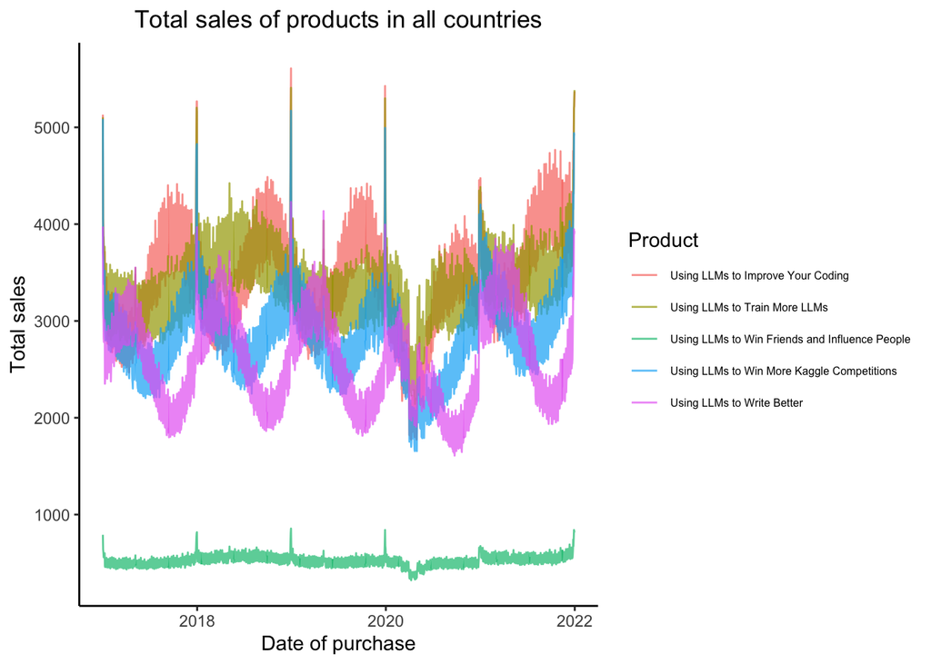

Figure 4.4: Product wise sales globally

```r
df_prod_sale <- df_train %>% group_by(date,product) %>% summarise(tot_sold =  sum(num_sold))

pl4 <-ggplot(data = df_prod_sale,
         aes(x = date, y = tot_sold, color = product),
         group = date) + geom_line(alpha = 0.7) + theme_classic() + ggtitle("Total sales of products in all countries") + labs(y = "Total sales", x = "Date of purchase", color =
                                                                                                          "Product") + theme(plot.title = element_text(hjust = 0.5),legend.text = element_text(size=6))

pl4
```

Based on figure 4.4, we can observe that

💡 there is a **sinusoidal** seasonality in the sales of most Kaggle products. However, the product “Using LLMs to Win Friends and Influence People” does not show much seasonality and have much lower sales compared to the rest of the products. 💡